# Cell_annotations

Ville Lehtonen

11/3/2020

# Cell annotations

This script uses SingleR (https://github.com/LTLA/SingleR) to perform the mapping of primary data cells into the reference data cell types

## 1. Load packages and data

### 1.1 Load packages

```r
library(SCORPIUS)
library(SingleR)
library(SingleCellExperiment)
library(reshape)
library(scater)
library(scran)
library(data.table)
library(gridExtra)
library(BBmisc)
library(tidyr)
library(ggpubr)
library(ggplot2)
library(grid)
library(RColorBrewer)
```

### 1.2 Load pre-calculated data

**Single Cell Experiments**

```r
# Load pre-processed sce objects
denoised.sce <- readRDS("./../saved/R_objects/denoised_sce_clust")
denoised.sce.deMicheli <- readRDS("./../saved/R_objects/denoised_sce_deMicheli")
denoised.sce.dellOrso <- readRDS("./../saved/R_objects/denoised_sce_dellOrso")
```

**Cell cycle genes (from OSCA pipeline)**

```r
# Get OSCA cell cycle genes
cc.genes.osca <- readRDS("./../saved/R_objects/cc_genes_osca")

# Create new datasets where the cell cycle genes have been removed
denoised.sce.cc.genes <- denoised.sce[!(rownames(denoised.sce) %in% cc.genes.osca), ]
denoised.sce.deMicheli.cc.genes <- denoised.sce.deMicheli[!(rownames(denoised.sce.deMicheli) %in% cc.genes.osca), ]
denoised.sce.dellOrso.cc.genes <- denoised.sce.dellOrso[!(rownames(denoised.sce.dellOrso) %in% cc.genes.osca), ]
```

## 2. Prediction of cell types from De Micheli et al. (2020) dataset

### 2.1 All genes

#### 2.1.1 Cell annotations

**Load pre-calculated predictions (if available)**

```r
# Load pre-saved prediction objects
pred.deMicheli <- readRDS("./../saved/R_objects/pred_deMicheli")

# Print the de genes used
de.genes.pred.deMicheli <- metadata(pred.deMicheli)$common.genes
print(de.genes.pred.deMicheli)
```

```
##    [1] "Tpm2"          "Pvalb"         "Eno3"          "Myl1"
##    [5] "Tnnc2"         "Tcap"          "Car3"          "Cox6a2"
##    [9] "Pgam2"         "Mylpf"         "Mb"            "Tnni2"
##   [13] "Tnnt3"         "Acta1"         "Tpm1"          "Ckm"
##   [17] "Atp2a1"        "Chchd10"       "Cox8b"         "Myoz1"
##   [21] "Cox5a"         "Actn3"         "Tpi1"          "Cox7a1"
##   [25] "Cox7b"         "Aldoa"         "Ak1"           "Vdac1"
##   [29] "Atp5o"         "Mpc1"          "Ndufc1"        "Hspb6"
##   [33] "Ndufb8"        "Mpc2"          "Cycs"          "Ndufa5"
##   [37] "Ndufa3"        "Mrpl42"        "Ndufa12"       "Myot"
##   [41] "Ndufv2"        "Uqcrfs1"       "Pygm"          "Ndufs7"
##   [45] "Sdhb"          "Ugp2"          "Adssl1"        "Gapdh"
##   [49] "Slc25a4"       "Bola3"         "Ndufb2"        "Atp5g1"
##   [53] "Uqcc2"         "Ptp4a3"        "Ndufv3"        "2010107E04Rik"
##   [57] "Tcea3"         "Tuba4a"        "Ndufs5"        "Ndufs6"
```

[output cut: 293 more lines]

```r
# Assign cell types to primary data
denoised.sce$cell_type_deMicheli <- pred.deMicheli$pruned.labels
```

**Perform cell annotation using SingleR (optional)**

```r
pred.deMicheli <- SingleR(test = denoised.sce,
                          assay.type.test = "logcounts",
                          ref = denoised.sce.deMicheli,
                          labels = denoised.sce.deMicheli$cell_type)

# Assign cell types to primary data
denoised.sce$cell_type_deMicheli <- pred.deMicheli$pruned.labels

#saveRDS(pred.deMicheli, file = "./../saved/R_objects/pred_deMicheli")
```

#### 2.1.2 Diagnostic plots

**Diagnostics**

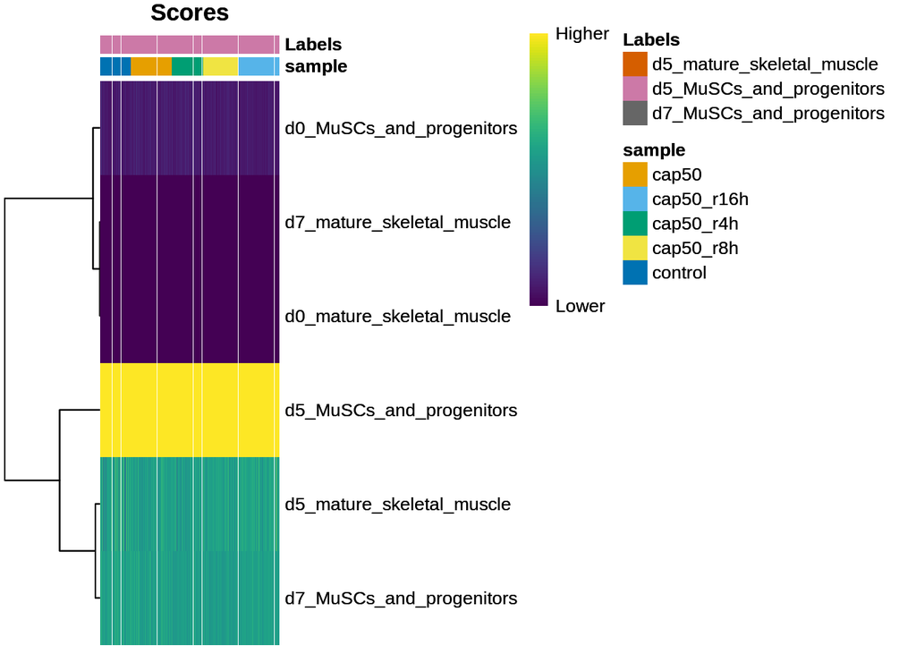

```r
# Score heatmap
plotScoreHeatmap(pred.deMicheli, annotation_col = as.data.frame(colData(denoised.sce)[, "sample", drop = FALSE]), width = 10)
```

```r
# Remove low-quality cells
to.remove <- pruneScores(pred.deMicheli, min.diff.next = 0.1)
table(Label=pred.deMicheli$labels, Removed=to.remove)
```

```
##                            Removed
## Label                       FALSE  TRUE
##   d5_mature_skeletal_muscle     0    18
##   d5_MuSCs_and_progenitors   1355 20427
##   d7_MuSCs_and_progenitors      0     8
```

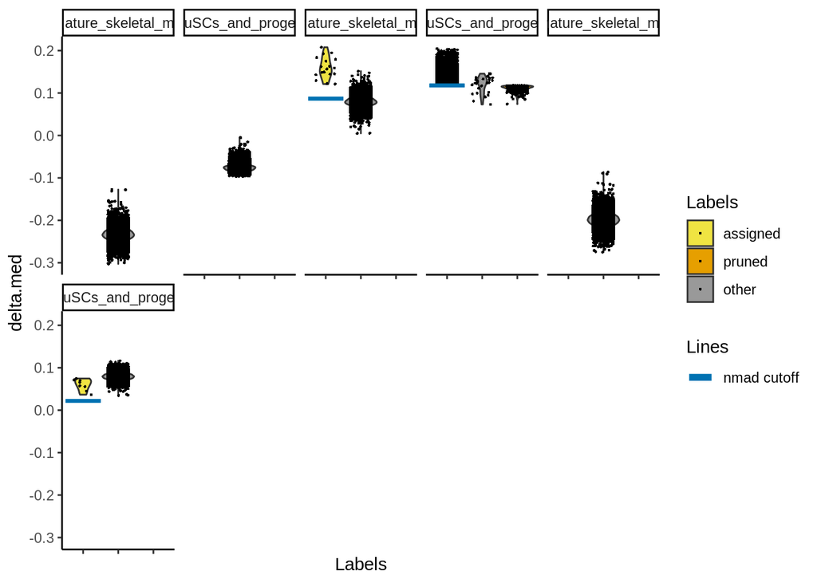

```r
# Delta distribution
plotScoreDistribution(results = pred.deMicheli, show = "delta.med")
```

**Pdf documents**

```r
# Visualize the score matrix
pdf("./../saved/figures/deMicheli_score_heatmap.pdf", width = 30, height = 50)
plotScoreHeatmap(pred.deMicheli,
                 annotation_col = as.data.frame(colData(denoised.sce)[, "sample", drop = FALSE]), width = 10)
dev.off()

to.remove <- pruneScores(pred.deMicheli, min.diff.next=0.1)
table(Label=pred.deMicheli$labels, Removed=to.remove)


# Delta distribution
pdf("./../saved/figures/deMicheli_score_distribution.pdf", width = 20, height = 15)
plotScoreDistribution(results = pred.deMicheli, show = "delta.med")
dev.off()

# Get marker genes
all.markers.deMicheli <- metadata(pred.deMicheli)$de.genes

# Write markers for each sample into a csv file
all.markers.deMicheli.df <- data.table("d0_mature_skeletal_muscle" = unique(unlist(all.markers.deMicheli$d0_mature_skeletal_muscle)),
                                       "d0_MuSCs_and_progenitors" = unique(unlist(all.markers.deMicheli$d0_MuSCs_and_progenitors)),
                                       "d5_mature_skeletal_muscle" = unique(unlist(all.markers.deMicheli$d5_mature_skeletal_muscle)),
                                       "d5_MuSCs_and_progenitors" = unique(unlist(all.markers.deMicheli$d5_MuSCs_and_progenitors)),
                                       "d7_mature_skeletal_muscle" = unique(unlist(all.markers.deMicheli$d7_mature_skeletal_muscle)),
                                       "d7_MuSCs_and_progenitors" = unique(unlist(all.markers.deMicheli$d7_MuSCs_and_progenitors)))
write.csv(all.markers.deMicheli.df, file ="./../saved/tables/all_markers_deMicheli.csv")

# Examine the expression of the marker genes for each label in the test dataset
pdf("./../saved/figures/cell_annotation_heatmap_deMicheli_d0_muscle.pdf")
plotHeatmap(denoised.sce,
            order_columns_by="cell_type_deMicheli",
            features=unique(unlist(all.markers.deMicheli$d0_mature_skeletal_muscle)),
            fontsize_row = 2)
dev.off()
pdf("./../saved/figures/cell_annotation_heatmap_deMicheli_d0_musc.pdf")
plotHeatmap(denoised.sce,
            order_columns_by="cell_type_deMicheli",
            features=unique(unlist(all.markers.deMicheli$d0_MuSCs_and_progenitors)),
            fontsize_row = 2)
dev.off()
pdf("./../saved/figures/cell_annotation_heatmap_deMicheli_d5_muscle.pdf")
plotHeatmap(denoised.sce,
            order_columns_by="cell_type_deMicheli",
            features=unique(unlist(all.markers.deMicheli$d5_mature_skeletal_muscle)),
            fontsize_row = 2)
dev.off()
pdf("./../saved/figures/cell_annotation_heatmap_deMicheli_d5_musc.pdf")
plotHeatmap(denoised.sce,
            order_columns_by="cell_type_deMicheli",
            features=unique(unlist(all.markers.deMicheli$d5_MuSCs_and_progenitors)),
            fontsize_row = 2)
dev.off()
pdf("./../saved/figures/cell_annotation_heatmap_deMicheli_d7_muscle.pdf")
plotHeatmap(denoised.sce,
            order_columns_by="cell_type_deMicheli",
            features=unique(unlist(all.markers.deMicheli$d7_mature_skeletal_muscle)),
            fontsize_row = 2)
dev.off()
pdf("./../saved/figures/cell_annotation_heatmap_deMicheli_d7_musc.pdf")
plotHeatmap(denoised.sce,
            order_columns_by="cell_type_deMicheli",
            features=unique(unlist(all.markers.deMicheli$d7_MuSCs_and_progenitors)),
            fontsize_row = 2)
dev.off()
```

### 2.2 Without cell cycle genes

#### 2.2.1 Cell annotations without cc genes

**Load pre-calculated predictions (if available)**

```r
pred.deMicheli.cc.genes <- readRDS("./../saved/R_objects/pred_deMicheli_cc_genes")

# Assign cell types to primary data
denoised.sce.cc.genes$cell_type_deMicheli <- pred.deMicheli.cc.genes$pruned.labels
```

**Perform cell annotation using SingleR (optional)**

```r
pred.deMicheli.cc.genes <- SingleR(test = denoised.sce.cc.genes,
                                   assay.type.test = "logcounts",
                                   ref = denoised.sce.deMicheli.cc.genes,
                                   labels = denoised.sce.deMicheli.cc.genes$cell_type)

# Assign cell types to primary data
denoised.sce.cc.genes$cell_type_deMicheli <- pred.deMicheli.cc.genes$pruned.labels

#saveRDS(pred.deMicheli.cc.genes, file = "./../saved/R_objects/pred_deMicheli_cc_genes")
```

#### 2.2.2 Diagnostic plots without cc genes (pdf documents)

**Diagnostic plots**

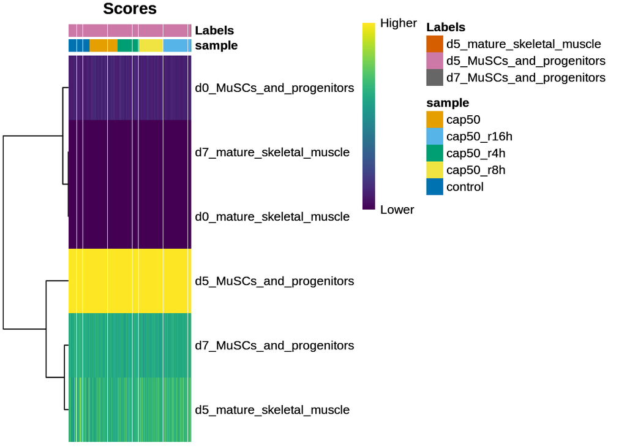

```r
# Score heatmap
plotScoreHeatmap(pred.deMicheli.cc.genes,
                 annotation_col = as.data.frame(colData(denoised.sce.cc.genes)[, "sample", drop = FALSE]), width = 10)
```

```r
# Remove low-quality cells
to.remove <- pruneScores(pred.deMicheli.cc.genes, min.diff.next=0.1)
table(Label=pred.deMicheli.cc.genes$labels, Removed=to.remove)
```

```
##                            Removed
## Label                       FALSE  TRUE
##   d5_mature_skeletal_muscle     0    27
##   d5_MuSCs_and_progenitors   9247 12453
##   d7_MuSCs_and_progenitors      0    81
```

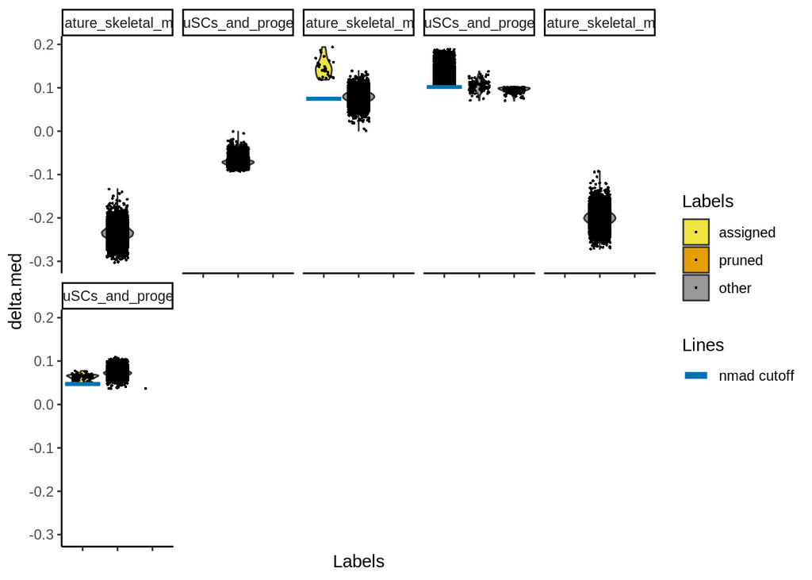

```r
# Delta distribution
plotScoreDistribution(results = pred.deMicheli.cc.genes, show = "delta.med")
```

**Pdf files**

```r
# Visualize the score matrix
pdf("./../saved/figures/deMicheli_cc_genes_score_heatmap.pdf", width = 30, height = 50)
plotScoreHeatmap(pred.deMicheli.cc.genes,
                 annotation_col = as.data.frame(colData(denoised.sce.cc.genes)[, "sample", drop = FALSE]), width = 10)
dev.off()

to.remove <- pruneScores(pred.deMicheli.cc.genes, min.diff.next=0.1)
table(Label=pred.deMicheli.cc.genes$labels, Removed=to.remove)


# Delta distribution
pdf("./../saved/figures/deMicheli_cc_genes_score_distribution.pdf", width = 20, height = 15)
plotScoreDistribution(results = pred.deMicheli.cc.genes, show = "delta.med")
dev.off()

# Get marker genes
all.markers.deMicheli <- metadata(pred.deMicheli.cc.genes)$de.genes

# Examine the expression of the marker genes for each label in the test dataset
pdf("./../saved/figures/cell_annotation_heatmap_deMicheli_cc_genes_d0_muscle.pdf")
plotHeatmap(denoised.sce.cc.genes,
            order_columns_by="cell_type_deMicheli",
            features=unique(unlist(all.markers.deMicheli$d0_mature_skeletal_muscle)),
            fontsize_row = 2)
dev.off()
pdf("./../saved/figures/cell_annotation_heatmap_deMicheli_cc_genes_d0_musc.pdf")
plotHeatmap(denoised.sce.cc.genes,
            order_columns_by="cell_type_deMicheli",
            features=unique(unlist(all.markers.deMicheli$d0_MuSCs_and_progenitors)),
            fontsize_row = 2)
dev.off()
pdf("./../saved/figures/cell_annotation_heatmap_deMicheli_cc_genes_d5_muscle.pdf")
plotHeatmap(denoised.sce.cc.genes,
            order_columns_by="cell_type_deMicheli",
            features=unique(unlist(all.markers.deMicheli$d5_mature_skeletal_muscle)),
            fontsize_row = 2)
dev.off()
pdf("./../saved/figures/cell_annotation_heatmap_deMicheli_cc_genes_d5_musc.pdf")
plotHeatmap(denoised.sce.cc.genes,
            order_columns_by="cell_type_deMicheli",
            features=unique(unlist(all.markers.deMicheli$d5_MuSCs_and_progenitors)),
            fontsize_row = 2)
dev.off()
pdf("./../saved/figures/cell_annotation_heatmap_deMicheli_cc_genes_d7_muscle.pdf")
plotHeatmap(denoised.sce.cc.genes,
            order_columns_by="cell_type_deMicheli",
            features=unique(unlist(all.markers.deMicheli$d7_mature_skeletal_muscle)),
            fontsize_row = 2)
dev.off()
pdf("./../saved/figures/cell_annotation_heatmap_deMicheli_cc_genes_d7_musc.pdf")
plotHeatmap(denoised.sce.cc.genes,
            order_columns_by="cell_type_deMicheli",
            features=unique(unlist(all.markers.deMicheli$d7_MuSCs_and_progenitors)),
            fontsize_row = 2)
dev.off()
```

### 2.3 Refined cell mapping based on smaller segments on the trajectory

#### 2.3.1 All cell types

##### 2.3.1.1 Cell annotations with all cell types

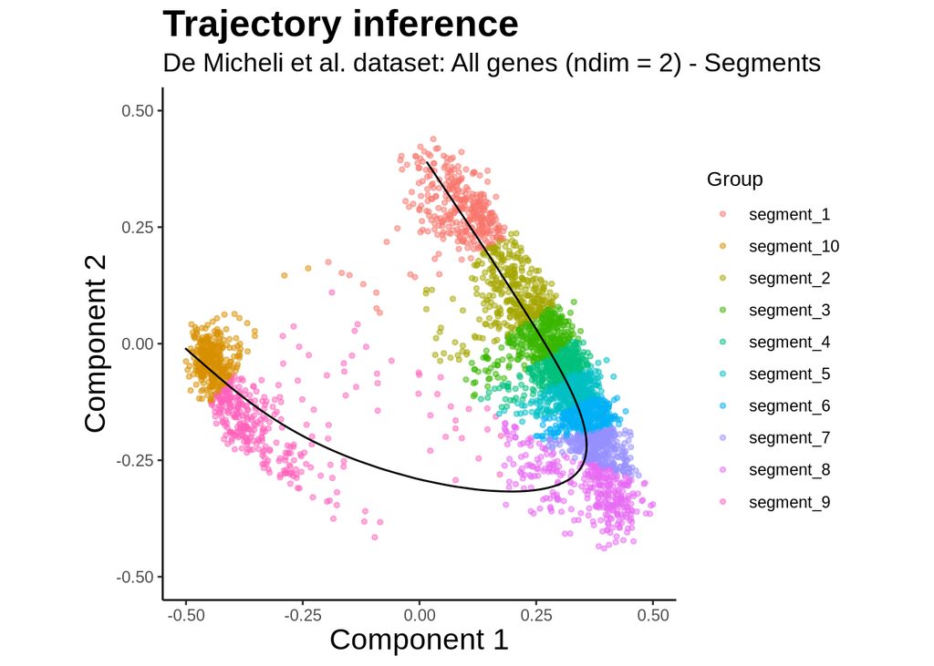

```r
# Trajectory building
expression.deMicheli <- as.matrix(t(logcounts(denoised.sce.deMicheli)))
set.seed(123)
space.deMicheli <- reduce_dimensionality(expression.deMicheli, dist = "spearman", ndim = 2)
set.seed(123)
traj.deMicheli <- infer_trajectory(space.deMicheli)
traj.deMicheli <- reverse_trajectory(traj.deMicheli)

# Sort cells based on their progression
ordered <- sort(traj.deMicheli$time, decreasing = FALSE)

# Split cells into 10 segments based on their pseudo time value
n = 10
ordered_chunks = chunk(ordered, n.chunks = 10, shuffle = FALSE)

# Label cells by their segment
denoised.sce.deMicheli$segment[colnames(denoised.sce.deMicheli) %in% names(ordered_chunks[[1]])] <- "segment_1"
denoised.sce.deMicheli$segment[colnames(denoised.sce.deMicheli) %in% names(ordered_chunks[[2]])] <- "segment_2"
denoised.sce.deMicheli$segment[colnames(denoised.sce.deMicheli) %in% names(ordered_chunks[[3]])] <- "segment_3"
denoised.sce.deMicheli$segment[colnames(denoised.sce.deMicheli) %in% names(ordered_chunks[[4]])] <- "segment_4"
denoised.sce.deMicheli$segment[colnames(denoised.sce.deMicheli) %in% names(ordered_chunks[[5]])] <- "segment_5"
denoised.sce.deMicheli$segment[colnames(denoised.sce.deMicheli) %in% names(ordered_chunks[[6]])] <- "segment_6"
denoised.sce.deMicheli$segment[colnames(denoised.sce.deMicheli) %in% names(ordered_chunks[[7]])] <- "segment_7"
denoised.sce.deMicheli$segment[colnames(denoised.sce.deMicheli) %in% names(ordered_chunks[[8]])] <- "segment_8"
denoised.sce.deMicheli$segment[colnames(denoised.sce.deMicheli) %in% names(ordered_chunks[[9]])] <- "segment_9"
denoised.sce.deMicheli$segment[colnames(denoised.sce.deMicheli) %in% names(ordered_chunks[[10]])] <- "segment_10"
segment.deMicheli <- as.factor(denoised.sce.deMicheli$segment)

draw_trajectory_plot(space = space.deMicheli,
                     progression_group = segment.deMicheli,
                     path = traj.deMicheli$path,
                     point_size = 1,
                     point_alpha = 0.5,
                     contour = FALSE) +
  ggtitle("Trajectory inference",
          subtitle = "De Micheli et al. dataset: All genes (ndim = 2) - Segments") +
  theme(plot.title = element_text(size = 20, face = "bold"),
        plot.subtitle = element_text(size = 14),
        axis.title = element_text(size = 16))
```

**Calculate singleR predictions (optional)**

```r
pred.segments <- SingleR(test = denoised.sce,
                         assay.type.test = "logcounts",
                         ref = denoised.sce.deMicheli,
                         labels = denoised.sce.deMicheli$segment)

#saveRDS(pred.segments, file = "./../saved/R_objects/pred_segments")

# Inspect the predictions
table(denoised.sce$sample, pred.segments.d5$pruned.labels)
```

**Load prediction results (if pre-saved prediction object available)**

```r
pred.segments <- readRDS("./../saved/R_objects/pred_segments")

# Inspect the predictions
tab.deMicheli.d5 <- table(denoised.sce$sample, pred.segments$pruned.labels)
```

##### 2.3.1.2 Diagnostic plots with all cell types grouped into segments (pdf documents)

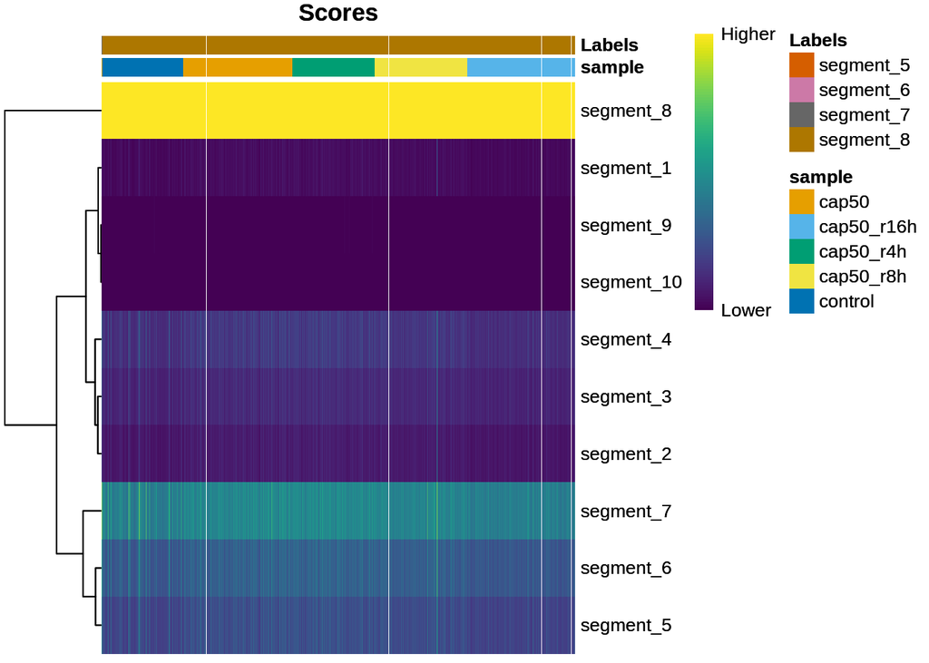

```r
# Visualize the score matrix
plotScoreHeatmap(pred.segments,
                 annotation_col = as.data.frame(colData(denoised.sce)[, "sample", drop = FALSE]), width = 10)
```

```r
# Remove low-quality cells
to.remove <- pruneScores(pred.segments, min.diff.next = 0.1)
table(Label=pred.segments$labels, Removed=to.remove)
```

```
##            Removed
## Label       FALSE  TRUE
##   segment_5     0     1
##   segment_6     0     5
##   segment_7     0    36
##   segment_8  4831 16935
```

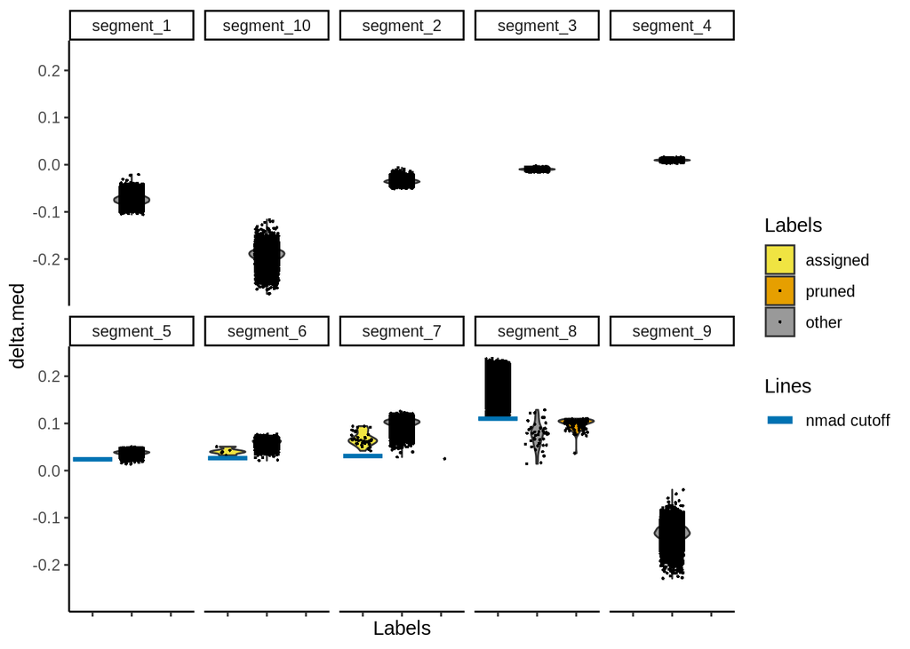

```r
# Delta distribution
plotScoreDistribution(results = pred.segments, show = "delta.med")
```

#### 2.3.2 D5 MuSCs and progenitors only

##### 2.3.2.1 Cell annotations with D5 MuSCs & progenitors

```r
# Sort cells by their pseudo time value
ordered <- sort(traj.deMicheli$time, decreasing = FALSE)

# Subset only D5 samples
d5.muscs <- names(ordered) %in% colnames(denoised.sce.deMicheli[, denoised.sce.deMicheli$cell_type == "d5_MuSCs_and_progenitors"])
ordered.d5 <- ordered[d5.muscs]

# Split cells into 10 segments based on their pseudo time value
n = 10
ordered_chunks.d5 = chunk(ordered.d5, n.chunks = 10, shuffle = FALSE)

# Inspect min / max values of each segment
df.values <- data.frame(segment = c(1:10),
                        min_pseudo_time_value = c(min(ordered_chunks.d5[[1]]),
                                min(ordered_chunks.d5[[2]]),
                                min(ordered_chunks.d5[[3]]),
                                min(ordered_chunks.d5[[4]]),
                                min(ordered_chunks.d5[[5]]),
                                min(ordered_chunks.d5[[6]]),
                                min(ordered_chunks.d5[[7]]),
                                min(ordered_chunks.d5[[8]]),
                                min(ordered_chunks.d5[[9]]),
                                min(ordered_chunks.d5[[10]])),
                        max_pseudo_time_value = c(max(ordered_chunks.d5[[1]]),
                                max(ordered_chunks.d5[[2]]),
                                max(ordered_chunks.d5[[3]]),
                                max(ordered_chunks.d5[[4]]),
                                max(ordered_chunks.d5[[5]]),
                                max(ordered_chunks.d5[[6]]),
                                max(ordered_chunks.d5[[7]]),
                                max(ordered_chunks.d5[[8]]),
                                max(ordered_chunks.d5[[9]]),
                                max(ordered_chunks.d5[[10]])))
df.values
```

```
##    segment min_pseudo_time_value max_pseudo_time_value
## 1        1            0.08757446             0.2473111
## 2        2            0.24764385             0.2846039
## 3        3            0.28469685             0.3100546
## 4        4            0.31018240             0.3327062
## 5        5            0.33295258             0.3568754
## 6        6            0.35713211             0.3805084
## 7        7            0.38060662             0.4007076
## 8        8            0.40138115             0.4212522
## 9        9            0.42125222             0.4412573
## 10      10            0.44125731             0.6945844
```

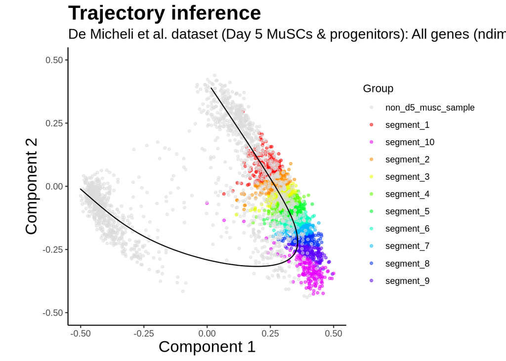

```r
# Label cells by their segment
denoised.sce.deMicheli$segment.d5[colnames(denoised.sce.deMicheli) %in% names(ordered_chunks.d5[[1]])] <- "segment_1"
denoised.sce.deMicheli$segment.d5[colnames(denoised.sce.deMicheli) %in% names(ordered_chunks.d5[[2]])] <- "segment_2"
denoised.sce.deMicheli$segment.d5[colnames(denoised.sce.deMicheli) %in% names(ordered_chunks.d5[[3]])] <- "segment_3"
denoised.sce.deMicheli$segment.d5[colnames(denoised.sce.deMicheli) %in% names(ordered_chunks.d5[[4]])] <- "segment_4"
denoised.sce.deMicheli$segment.d5[colnames(denoised.sce.deMicheli) %in% names(ordered_chunks.d5[[5]])] <- "segment_5"
denoised.sce.deMicheli$segment.d5[colnames(denoised.sce.deMicheli) %in% names(ordered_chunks.d5[[6]])] <- "segment_6"
denoised.sce.deMicheli$segment.d5[colnames(denoised.sce.deMicheli) %in% names(ordered_chunks.d5[[7]])] <- "segment_7"
denoised.sce.deMicheli$segment.d5[colnames(denoised.sce.deMicheli) %in% names(ordered_chunks.d5[[8]])] <- "segment_8"
denoised.sce.deMicheli$segment.d5[colnames(denoised.sce.deMicheli) %in% names(ordered_chunks.d5[[9]])] <- "segment_9"
denoised.sce.deMicheli$segment.d5[colnames(denoised.sce.deMicheli) %in% names(ordered_chunks.d5[[10]])] <- "segment_10"

# Replace NA values with "non d5 samples"
denoised.sce.deMicheli$segment.d5 <- replace_na(denoised.sce.deMicheli$segment.d5, "non_d5_musc_sample")

# Factorize the segments
segment.deMicheli.d5 <- as.factor(denoised.sce.deMicheli$segment.d5)

# Draw trajectory plot
colpalette.segments <- rainbow(11)
names(colpalette.segments) <- c("segment_1", "segment_2", "segment_3", "segment_4", "segment_5", "segment_6", "segment_7", "segment_8", "segment_9", "segment_10", "non_d5_musc_sample")
colpalette.segments["non_d5_musc_sample"] <- "#DCDCDC" # set to white


draw_trajectory_plot(space = space.deMicheli,
                     progression_group = segment.deMicheli.d5,
                     progression_group_palette = colpalette.segments,
                     path = traj.deMicheli$path,
                     point_size = 1,
                     point_alpha = 0.5,
                     contour = FALSE) +
  ggtitle("Trajectory inference",
          subtitle = "De Micheli et al. dataset (Day 5 MuSCs & progenitors): All genes (ndim = 2) - Segments") +
  theme(plot.title = element_text(size = 20, face = "bold"),
        plot.subtitle = element_text(size = 14),
        axis.title = element_text(size = 16))
```

**Calculate singleR predictions (optional)**

```r
pred.segments.d5 <- SingleR(test = denoised.sce,
                            assay.type.test = "logcounts",
                            ref = denoised.sce.deMicheli,
                            labels = denoised.sce.deMicheli$segment.d5)

#saveRDS(pred.segments.d5, file = "./../saved/R_objects/pred_segments_d5")

# Inspect the predictions
table(denoised.sce$sample, pred.segments.d5$pruned.labels)
```

**Load prediction results (if pre-saved prediction object available)**

```r
pred.segments.d5 <- readRDS("./../saved/R_objects/pred_segments_d5")

# Print the de genes used
de.genes.pred.segments.d5 <- metadata(pred.segments.d5)$common.genes
print(de.genes.pred.segments.d5)
```

```
##    [1] "Acta1"         "Myl1"          "Mylpf"         "Xist"
##    [5] "Tnnc2"         "Ndufa5"        "Tpi1"          "Tnnt3"
##    [9] "Cycs"          "Ndufv3"        "Ckm"           "Atp5k"
##   [13] "Atp2a1"        "Bin1"          "Usmg5"         "Romo1"
##   [17] "Fkbp3"         "Tnni2"         "Ndufb2"        "Fxyd1"
##   [21] "Tpm2"          "Jsrp1"         "Ndufs8"        "Mdh1"
##   [25] "Lsm6"          "Uqcr11"        "Ndufa1"        "Ndrg2"
##   [29] "Tpm1"          "Ndufa3"        "Mrps21"        "mt-Nd3"
##   [33] "Pfdn2"         "Tmem256"       "Mrpl12"        "Higd1a"
##   [37] "Ldha"          "Ank1"          "Etfb"          "Chchd10"
##   [41] "Ndufv1"        "Aldoa"         "Atp5j2"        "Cryab"
##   [45] "Hspa9"         "Eno3"          "Cisd1"         "Psmd7"
##   [49] "Timm8b"        "Uqcr10"        "Psma6"         "Tmem147"
##   [53] "Vdac3"         "Tecr"          "Sdhc"          "Arpp19"
##   [57] "Sod2"          "Uqcrb"         "Bola3"         "Rwdd1"
```

[output cut: 583 more lines]

```r
# Inspect the predictions
tab.deMicheli.d5 <- table(denoised.sce$sample, pred.segments.d5$pruned.labels)
```

##### 2.3.2.2 Diagnostic plots with D5 MuSCs & progenitors (pdf documents)

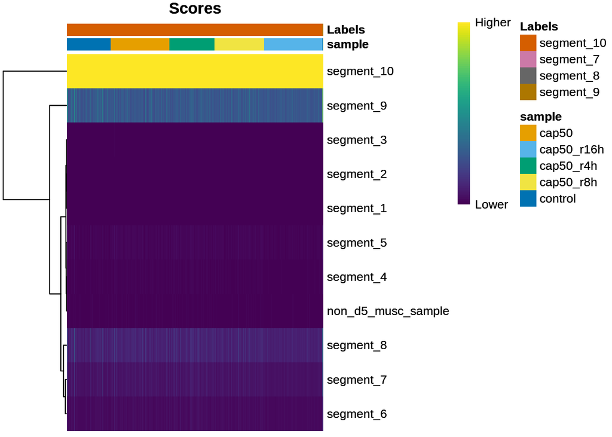

```r
# Visualize the score matrix
plotScoreHeatmap(pred.segments.d5,
                 annotation_col = as.data.frame(colData(denoised.sce)[, "sample", drop = FALSE]), width = 10)
```

```r
to.remove <- pruneScores(pred.segments.d5, min.diff.med=0.2)
table(Label=pred.segments.d5$labels, Removed=to.remove)
```

```
##             Removed
## Label        FALSE  TRUE
##   segment_10  9022 12732
##   segment_7      0     2
##   segment_8      0     5
##   segment_9      0    47
```

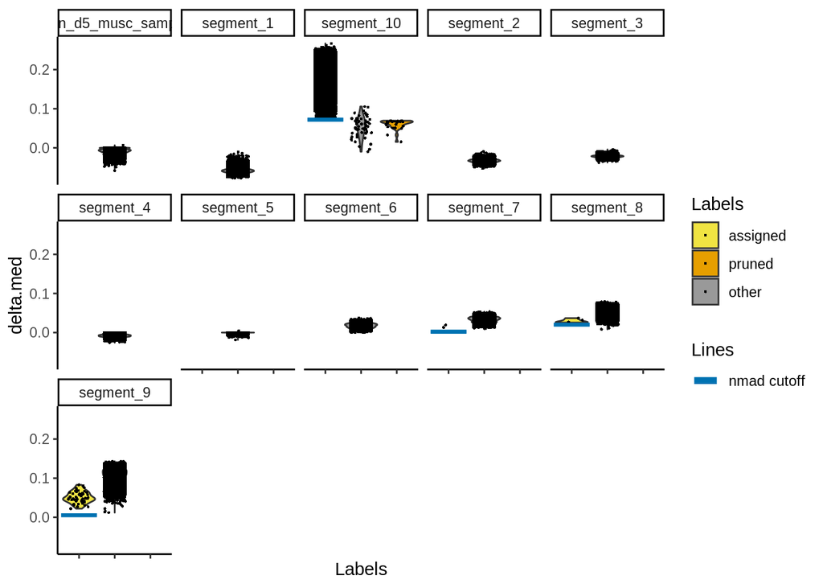

```r
# Delta distribution
plotScoreDistribution(results = pred.segments.d5, show = "delta.med")
```

##### 2.3.2.3 Visualization of segment 10 on trajectory

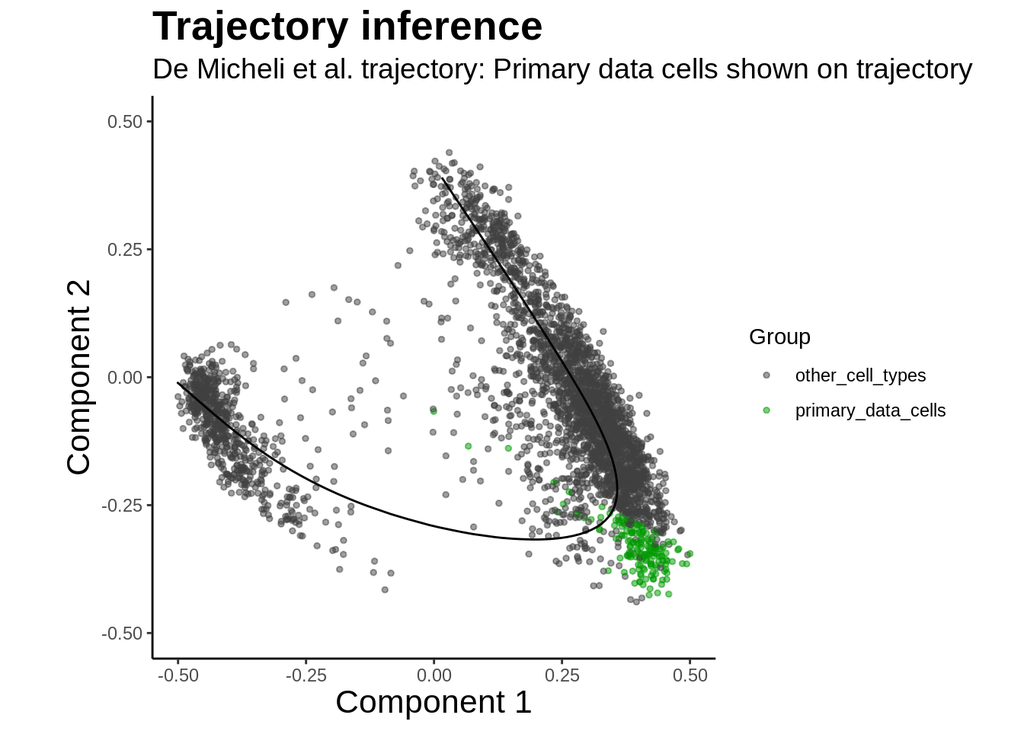

```r
# Group cells by segment 10 vs. all other cells
primary.data.cells <- denoised.sce.deMicheli$segment.d5 == "segment_10"
other.cells <- !primary.data.cells
denoised.sce.deMicheli$primary.cells[primary.data.cells] <- "primary_data_cells"
denoised.sce.deMicheli$primary.cells[other.cells] <- "other_cell_types"

# Define progression group
prog.group <- as.factor(denoised.sce.deMicheli$primary.cells)

# Define a custom color palette (black / green)
colpalette <- c('primary_data_cells' ="#009900",
                'other_cell_types' = "#404040")

# Draw trajectory plot
draw_trajectory_plot(space = space.deMicheli,
                     progression_group = prog.group,
                     progression_group_palette = colpalette,
                     path = traj.deMicheli$path,
                     point_size = 1,
                     point_alpha = 0.5,
                     contour = FALSE) +
  ggtitle("Trajectory inference",
          subtitle = "De Micheli et al. trajectory: Primary data cells shown on trajectory") +
  theme(plot.title = element_text(size = 20, face = "bold"),
        plot.subtitle = element_text(size = 14),
        axis.title = element_text(size = 16))
```

##### 2.3.2.4 Gene importances for Day 5 MuSCs

**Load pre-calculated gene importance objects (calculated in Trajectory_inference.Rmd script)**

```r
# Load gimp and modules objects
gimp.deMicheli <- readRDS("./../saved/R_objects/gimp_deMicheli")
modules.deMicheli <- readRDS("./../saved/R_objects/modules_deMicheli")

gimp.deMicheli$qvalue <- p.adjust(p = gimp.deMicheli$pvalue, method = "BH")
gene_sel.deMicheli <- gimp.deMicheli$gene[gimp.deMicheli$qvalue < .05]
expr_sel.deMicheli <- scale_quantile(expression.deMicheli[, gene_sel.deMicheli])
```

```r
# Identify candidate marker genes from the Day 5 sample
group_name.deMicheli.d5 <- as.factor(denoised.sce.deMicheli$segment.d5)

pdf("./../saved/figures/modules_heatmap_deMicheli_d5_segments.pdf")
draw_trajectory_heatmap(expr_sel.deMicheli,
                        time = traj.deMicheli$time,
                        progression_group = group_name.deMicheli.d5,
                        modules = modules.deMicheli,
                        show_labels_row = TRUE,
                        fontsize_row = 1)
dev.off()
```

## 3. Prediction of cell types from Dell’Orso et al. (2019) dataset

### 3.1 All genes

#### 3.1.1 Cell annotations

**Load pre-calculated predictions (if available)**

```r
# Load pre-saved prediction objects (with and without PMs)
pred.dellOrso <- readRDS("./../saved/R_objects/pred_dellOrso")
pred.dellOrso.f <- readRDS("./../saved/R_objects/pred_dellOrso_f")

# Print the de genes used
de.genes.pred.dellOrso <- metadata(pred.dellOrso)$common.genes
print(de.genes.pred.dellOrso)
```

```
##   [1] "Meg3"          "Gpx3"          "Cxcl1"         "Ubc"
##   [5] "Hmox1"         "Apoe"          "Zbtb20"        "Errfi1"
##   [9] "Hspa5"         "Malat1"        "Asb5"          "Pdpn"
##  [13] "H2-D1"         "Runx1"         "Sqstm1"        "Srsf5"
##  [17] "Crlf1"         "Ier5"          "Neat1"         "Mat2a"
##  [21] "Arid5b"        "Klf9"          "Zfand5"        "Ccnl1"
##  [25] "Txnrd1"        "Glul"          "Nfkb1"         "Cd82"
##  [29] "Fgfr1"         "Pde4b"         "Slc43a3"       "Son"
##  [33] "Ppp1r15a"      "Cd9"           "Vcam1"         "Slc3a2"
##  [37] "B2m"           "Flnc"          "Anxa5"         "Clic4"
##  [41] "Trib1"         "Ctsl"          "Sf3b1"         "Gsn"
##  [45] "Stat3"         "H2-K1"         "Egr1"          "Arl4d"
##  [49] "Pdia6"         "Hspb1"         "Itm2b"         "Emp1"
##  [53] "Srxn1"         "Pdlim4"        "Rbms1"         "Pmepa1"
##  [57] "Ier2"          "Maff"          "Etf1"          "Sec62"
```

[output cut: 201 more lines]

```r
de.genes.pred.dellOrso.f <- metadata(pred.dellOrso.f)$common.genes
print(de.genes.pred.dellOrso.f)
```

```
##   [1] "Meg3"          "Gpx3"          "Cxcl1"         "Ubc"
##   [5] "Hmox1"         "Apoe"          "Zbtb20"        "Errfi1"
##   [9] "Hspa5"         "Malat1"        "Asb5"          "Pdpn"
##  [13] "H2-D1"         "Runx1"         "Sqstm1"        "Srsf5"
##  [17] "Crlf1"         "Ier5"          "Neat1"         "Mat2a"
##  [21] "Arid5b"        "Klf9"          "Zfand5"        "Ccnl1"
##  [25] "Txnrd1"        "Glul"          "Nfkb1"         "Cd82"
##  [29] "Fgfr1"         "Pde4b"         "Slc43a3"       "Son"
##  [33] "Ppp1r15a"      "Cd9"           "Vcam1"         "Slc3a2"
##  [37] "B2m"           "Flnc"          "Anxa5"         "Clic4"
##  [41] "Trib1"         "Ctsl"          "Sf3b1"         "Gsn"
##  [45] "Stat3"         "H2-K1"         "Egr1"          "Arl4d"
##  [49] "Pdia6"         "Hspb1"         "Itm2b"         "Emp1"
##  [53] "Srxn1"         "Pdlim4"        "Rbms1"         "Pmepa1"
##  [57] "Ier2"          "Maff"          "Etf1"          "Sec62"
```

[output cut: 109 more lines]

```r
# Assign cell types to primary data
denoised.sce$cell_type_dellOrso <- pred.dellOrso$pruned.labels
denoised.sce$cell_type_dellOrso_f <- pred.dellOrso.f$pruned.labels
```

**Perform cell annotation using SingleR (optional)**

```r
########################
# With primary myoblasts
########################
pred.dellOrso <- SingleR(test = denoised.sce,
                         assay.type.test = "logcounts",
                         ref = denoised.sce.dellOrso,
                         labels = denoised.sce.dellOrso$cell_type)

# Assign cell types to primary data
denoised.sce$cell_type_dellOrso <- pred.dellOrso$pruned.labels

saveRDS(pred.dellOrso, file = "./../saved/R_objects/pred_dellOrso")

###########################
# Without primary myoblasts
###########################

# Filter out primary MBs
denoised.sce.dellOrso.f <- denoised.sce.dellOrso[, denoised.sce.dellOrso$cell_type != "Primary_MB"]

# SingleR prediction
pred.dellOrso.f <- SingleR(test = denoised.sce,
                         assay.type.test = "logcounts",
                         ref = denoised.sce.dellOrso.f,
                         labels = denoised.sce.dellOrso.f$cell_type)

saveRDS(pred.dellOrso.f, file = "pred_dellOrso_f")
```

#### 3.2.1 Diagnostic plots (pdf documents)

##### 3.2.1.1 With primary myoblasts

**diagnostics**

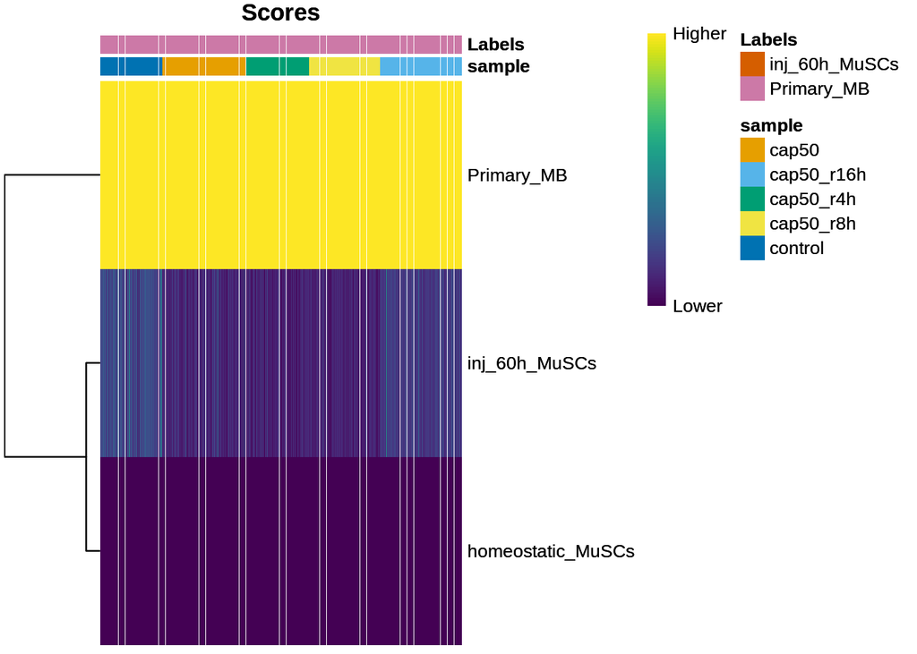

```r
# Score heatmap
plotScoreHeatmap(pred.dellOrso,  annotation_col = as.data.frame(colData(denoised.sce)[, "sample", drop = FALSE]))
```

```r
# Remove low-quality cells
to.remove <- pruneScores(pred.dellOrso, min.diff.next = 0.1)
table(Label=pred.dellOrso$labels, Removed=to.remove)
```

```
##                Removed
## Label           FALSE  TRUE
##   inj_60h_MuSCs     1    19
##   Primary_MB    21547   241
```

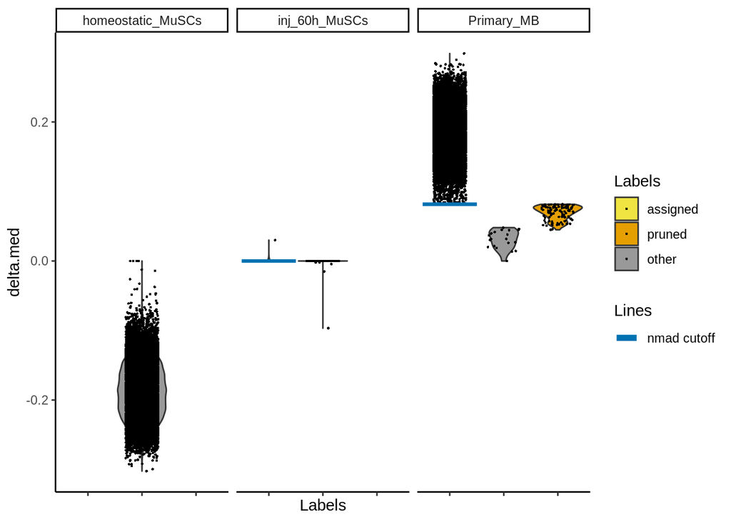

```r
# Delta distribution
plotScoreDistribution(pred.dellOrso, show = "delta.med")
```

**pdf document**

```r
# Visualize the score matrix
pdf("./../saved/figures/dellOrso_score_heatmap.pdf")
plotScoreHeatmap(pred.dellOrso,
                 annotation_col = as.data.frame(colData(denoised.sce)[, "sample", drop = FALSE]))
dev.off()

# Delta distribution
pdf("./../saved/figures/dellOrso_score_distribution.pdf")
plotScoreDistribution(pred.dellOrso, show = "delta.med")
dev.off()

# Get marker genes
all.markers.dellOrso <- metadata(pred.dellOrso)$de.genes

# Examine the expression of the marker genes for each label in the test dataset
pdf("./../saved/figures/cell_annotation_heatmap_dellOrso_homeostatic_muscs.pdf")
plotHeatmap(denoised.sce,
            order_columns_by="cell_type_dellOrso",
            features=unique(unlist(all.markers.dellOrso$homeostatic_MuSCs)),
            fontsize_row = 2)
dev.off()


pdf("./../saved/figures/cell_annotation_heatmap_dellOrso_inj_60h_muscs.pdf")
plotHeatmap(denoised.sce,
            order_columns_by="cell_type_dellOrso",
            features=unique(unlist(all.markers.dellOrso$inj_60h_MuSCs)),
            fontsize_row = 2)
dev.off()

pdf("./../saved/figures/cell_annotation_heatmap_dellOrso_primary_mb.pdf")
plotHeatmap(denoised.sce,
            order_columns_by="cell_type_dellOrso",
            features=unique(unlist(all.markers.dellOrso$Primary_MB)),
            fontsize_row = 2)
dev.off()
```

##### 3.2.1.1 Without primary myoblasts

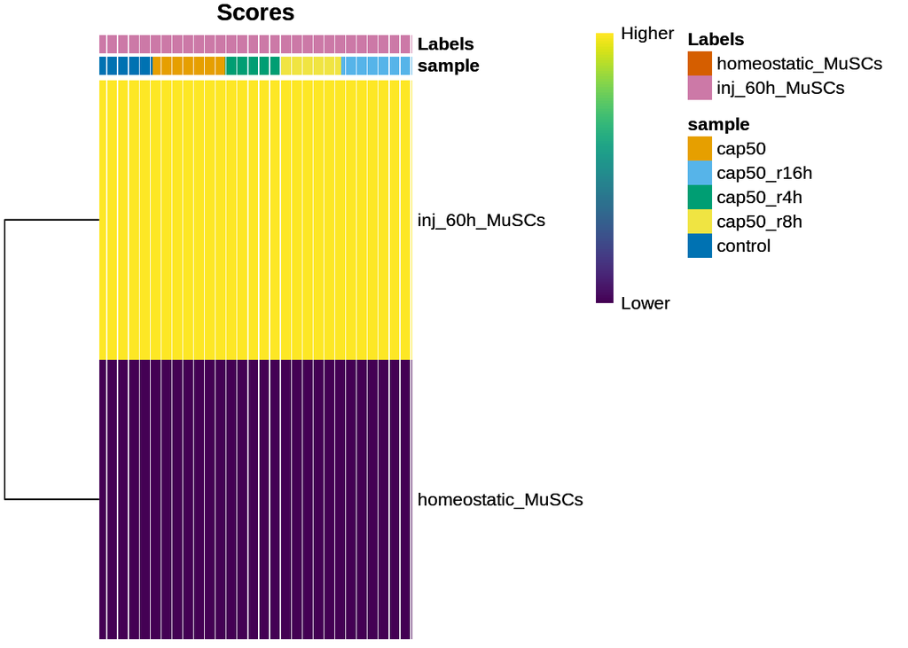

```r
# Score heatmap
plotScoreHeatmap(pred.dellOrso.f,  annotation_col = as.data.frame(colData(denoised.sce)[, "sample", drop = FALSE]))
```

```r
# Remove low-quality cells
to.remove <- pruneScores(pred.dellOrso.f, min.diff.next = 0.1)
table(Label=pred.dellOrso.f$labels, Removed=to.remove)
```

```
##                    Removed
## Label               FALSE  TRUE
##   homeostatic_MuSCs     1     1
##   inj_60h_MuSCs     21785    21
```

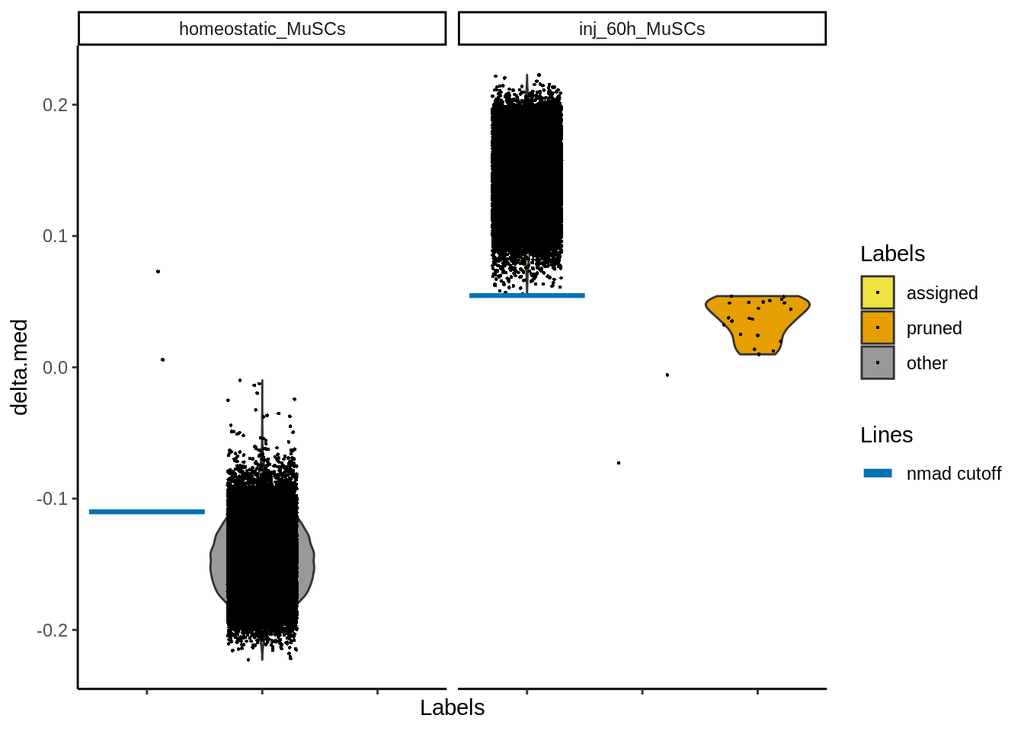

```r
# Delta distribution
plotScoreDistribution(pred.dellOrso.f, show = "delta.med")
```

**pdf document**

```r
# Visualize the score matrix
pdf("./../saved/figures/dellOrso_score_heatmap_f.pdf")
plotScoreHeatmap(pred.dellOrso.f,
                 annotation_col = as.data.frame(colData(denoised.sce)[, "sample", drop = FALSE]))
dev.off()

# Delta distribution
pdf("./../saved/figures/dellOrso_score_distribution_f.pdf")
plotScoreDistribution(pred.dellOrso.f, show = "delta.med")
dev.off()

# Get marker genes
all.markers.dellOrso <- metadata(pred.dellOrso.f)$de.genes

# Examine the expression of the marker genes for each label in the test dataset
pdf("./../saved/figures/cell_annotation_heatmap_dellOrso_homeostatic_muscs_f.pdf")
plotHeatmap(denoised.sce,
            order_columns_by="cell_type_dellOrso_f",
            features=unique(unlist(all.markers.dellOrso$homeostatic_MuSCs)),
            fontsize_row = 2)
dev.off()


pdf("./../saved/figures/cell_annotation_heatmap_dellOrso_inj_60h_muscs_f.pdf")
plotHeatmap(denoised.sce,
            order_columns_by="cell_type_dellOrso_f",
            features=unique(unlist(all.markers.dellOrso$inj_60h_MuSCs)),
            fontsize_row = 2)
dev.off()
```

### 3.2 Without cell cycle genes

#### 3.2.1 Cell annotations without cc genes using Dell’Orso dataset

**Load pre-calculated predictions (if available)**

```r
pred.dellOrso.cc.genes <- readRDS("./../saved/R_objects/pred_dellOrso_cc_genes")

# Assign cell types to primary data
denoised.sce.cc.genes$cell_type_dellOrso <- pred.dellOrso.cc.genes$pruned.labels
```

**Perform cell annotation using SingleR (optional)**

```r
pred.dellOrso.cc.genes <- SingleR(test = denoised.sce.cc.genes,
                                  assay.type.test = "logcounts",
                                  ref = denoised.sce.dellOrso.cc.genes,
                                  labels = denoised.sce.dellOrso.cc.genes$cell_type)

# Assign cell types to primary data
denoised.sce.cc.genes$cell_type_dellOrso <- pred.dellOrso.cc.genes$pruned.labels

#saveRDS(pred.dellOrso.cc.genes, file = "./../saved/R_objects/pred_dellOrso_cc_genes")
```

**diagnostics**

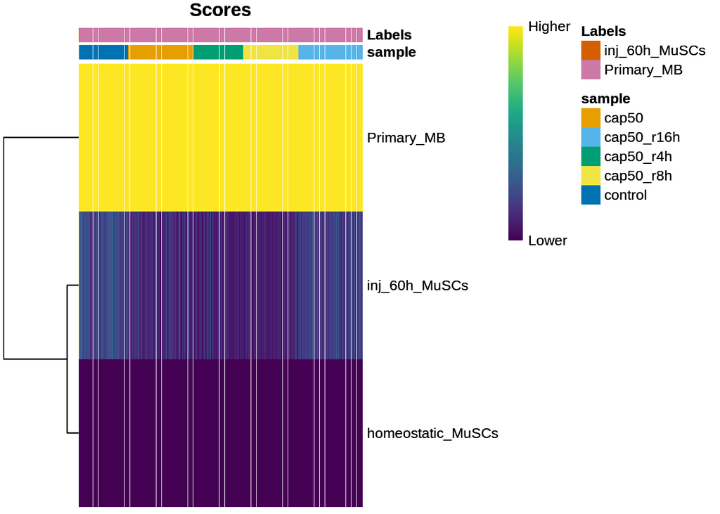

```r
# Score heatmap
plotScoreHeatmap(pred.dellOrso.cc.genes,
                 annotation_col = as.data.frame(colData(denoised.sce.cc.genes)[, "sample", drop = FALSE]), width = 10)
```

```r
# Remove low-quality cells
to.remove <- pruneScores(pred.dellOrso.cc.genes, min.diff.next=0.1)
table(Label=pred.dellOrso.cc.genes$labels, Removed=to.remove)
```

```
##                Removed
## Label           FALSE  TRUE
##   inj_60h_MuSCs     1    45
##   Primary_MB    21336   426
```

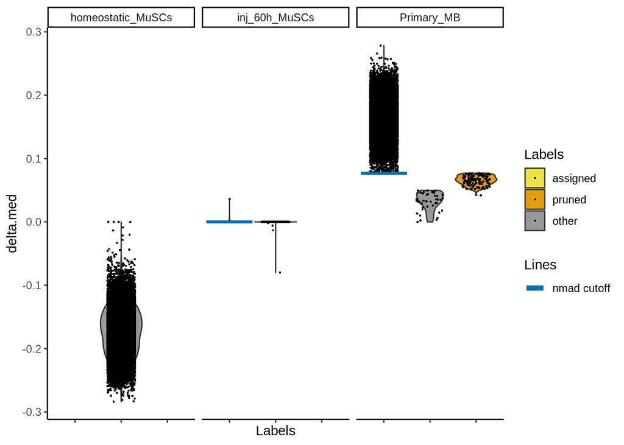

```r
# Delta distribution
plotScoreDistribution(results = pred.dellOrso.cc.genes, show = "delta.med")
```

```r
# Visualize the score matrix
pdf("./../saved/figures/dellOrso_cc_genes_score_heatmap.pdf", width = 30, height = 50)
plotScoreHeatmap(pred.dellOrso.cc.genes,
                 annotation_col = as.data.frame(colData(denoised.sce.cc.genes)[, "sample", drop = FALSE]), width = 10)
dev.off()

# Delta distribution
pdf("./../saved/figures/dellOrso_cc_genes_score_distribution.pdf", width = 20, height = 15)
plotScoreDistribution(results = pred.dellOrso.cc.genes, show = "delta.med")
dev.off()

# Get marker genes
all.markers.dellOrso <- metadata(pred.dellOrso.cc.genes)$de.genes

# Examine the expression of the marker genes for each label in the test dataset
pdf("./../saved/figures/cell_annotation_heatmap_dellOrso_cc_genes_homeostatic_muscs.pdf")
plotHeatmap(denoised.sce.cc.genes,
            order_columns_by="cell_type_dellOrso",
            features=unique(unlist(all.markers.dellOrso$homeostatic_MuSCs)),
            fontsize_row = 2)
dev.off()


pdf("./../saved/figures/cell_annotation_heatmap_dellOrso_cc_genes_inj_60h_muscs.pdf")
plotHeatmap(denoised.sce.cc.genes,
            order_columns_by="cell_type_dellOrso",
            features=unique(unlist(all.markers.dellOrso$inj_60h_MuSCs)),
            fontsize_row = 2)
dev.off()

pdf("./../saved/figures/cell_annotation_heatmap_dellOrso_cc_genes_primary_mb.pdf")
plotHeatmap(denoised.sce.cc.genes,
            order_columns_by="cell_type_dellOrso",
            features=unique(unlist(all.markers.dellOrso$Primary_MB)),
            fontsize_row = 2)
dev.off()
```

### 3.3 Save the DE genes used in SingleR predictions as .csv file

```r
write.csv(de.genes.pred.deMicheli, file = "./../saved/tables/de_genes_pred_deMicheli.csv")
write.csv(de.genes.pred.segments.d5, file = "./../saved/tables/de_genes_pred_deMicheli_segments_d5MuSCs.csv")
write.csv(de.genes.pred.dellOrso, file = "./../saved/tables/de_genes_pred_dellOrso.csv")
write.csv(de.genes.pred.dellOrso.f, file = "./../saved/tables/de_genes_pred_dellOrso_no_pm.csv")
```

## 4. Prediction of De Micheli cell types from Dell’Orso cell types and vice versa

### 4.1 Cell annotations

**Load pre-calculated predictions (if available)**

```r
# Dell'Orso as reference (de Micheli as test)
pred.reference <- readRDS("./../saved/R_objects/pred_reference")

# De Micheli as reference (Dell'Orso as test)
pred.reference2 <- readRDS("./../saved/R_objects/pred_reference2")
```

**Perform cell annotation using SingleR (optional)**

```r
# Dell'Orso as reference
pred.reference <- SingleR(test = denoised.sce.deMicheli,
                          assay.type.test = "logcounts",
                          ref = denoised.sce.dellOrso,
                          labels = denoised.sce.dellOrso$cell_type)
#saveRDS(pred.reference, file = "./../saved/R_objects/pred_reference")

# De Micheli as reference
pred.reference2 <- SingleR(test = denoised.sce.dellOrso,
                          assay.type.test = "logcounts",
                          ref = denoised.sce.deMicheli,
                          labels = denoised.sce.deMicheli$cell_type)
#saveRDS(pred.reference2, file = "./../saved/R_objects/pred_reference2")
```

### 4.2 Visualization of predictions

```r
# Dell'Orso as reference:
table(pred.reference$pruned.labels)
```

```
##
## homeostatic_MuSCs     inj_60h_MuSCs        Primary_MB
##               355              1166              1802
```

```r
(table(pred.reference$pruned.labels, denoised.sce.deMicheli$cell_type))
```

```
##
##                     d0_mature_skeletal_muscle d0_MuSCs_and_progenitors
##   homeostatic_MuSCs                         1                       85
##   inj_60h_MuSCs                           401                       18
##   Primary_MB                               72                        0
##
##                     d5_mature_skeletal_muscle d5_MuSCs_and_progenitors
##   homeostatic_MuSCs                         0                       32
##   inj_60h_MuSCs                            22                      356
##   Primary_MB                              149                     1251
##
##                     d7_mature_skeletal_muscle d7_MuSCs_and_progenitors
##   homeostatic_MuSCs                         0                      237
##   inj_60h_MuSCs                            69                      300
##   Primary_MB                               86                      244
```

```r
# DeMicheli as reference
table(pred.reference2$pruned.labels)
```

```
##
## d0_mature_skeletal_muscle  d0_MuSCs_and_progenitors d5_mature_skeletal_muscle
##                         1                      3011                       519
##  d5_MuSCs_and_progenitors d7_mature_skeletal_muscle  d7_MuSCs_and_progenitors
##                      3798                        14                      2193
```

```r
table(pred.reference2$pruned.labels, denoised.sce.dellOrso$cell_type)
```

```
##
##                             homeostatic_MuSCs inj_60h_MuSCs Primary_MB
##   d0_mature_skeletal_muscle                 1             0          0
##   d0_MuSCs_and_progenitors               2990            21          0
##   d5_mature_skeletal_muscle                 0           110        409
##   d5_MuSCs_and_progenitors                  0            13       3785
##   d7_mature_skeletal_muscle                 0             0         14
##   d7_MuSCs_and_progenitors                 70          2123          0
```

## 5. Visualization of cell annotation results

### 5.1 All genes

```r
# Inspection of predictions
table(pred.deMicheli$pruned.labels)
```

```
##
## d5_mature_skeletal_muscle  d5_MuSCs_and_progenitors  d7_MuSCs_and_progenitors
##                        18                     21521                         8
```

```r
table(pred.dellOrso$labels)
```

```
##
## inj_60h_MuSCs    Primary_MB
##            20         21788
```

```r
table(pred.dellOrso.f$labels)
```

```
##
## homeostatic_MuSCs     inj_60h_MuSCs
##                 2             21806
```

```r
tab.deMicheli <- t(table(pred.deMicheli$pruned.labels, denoised.sce$sample)[, c("control", "cap50", "cap50_r4h","cap50_r8h","cap50_r16h")])
tab.dellOrso <- t(table(pred.dellOrso$pruned.labels, denoised.sce$sample)[, c("control", "cap50", "cap50_r4h","cap50_r8h","cap50_r16h")])
tab.dellOrso.f <- t(table(pred.dellOrso.f$pruned.labels, denoised.sce$sample)[, c("control", "cap50", "cap50_r4h","cap50_r8h","cap50_r16h")])

tab.deMicheli
```

```
##
##              d5_mature_skeletal_muscle d5_MuSCs_and_progenitors
##   control                           12                     3722
##   cap50                              3                     4819
##   cap50_r4h                          0                     3802
##   cap50_r8h                          0                     4241
##   cap50_r16h                         3                     4937
##
##              d7_MuSCs_and_progenitors
##   control                           0
##   cap50                             4
##   cap50_r4h                         1
##   cap50_r8h                         0
##   cap50_r16h                        3
```

```r
tab.dellOrso
```

```
##
##              inj_60h_MuSCs Primary_MB
##   control                1       3743
##   cap50                  5       4965
##   cap50_r4h              2       3802
##   cap50_r8h              2       4252
##   cap50_r16h            10       4922
```

```r
tab.dellOrso.f
```

```
##
##              homeostatic_MuSCs inj_60h_MuSCs
##   control                    1          3749
##   cap50                      0          5020
##   cap50_r4h                  0          3810
##   cap50_r8h                  0          4255
##   cap50_r16h                 1          4951
```

```r
## 'melt' tables
df.deMicheli <- melt(t(tab.deMicheli))
colnames(df.deMicheli) <- c("cell_type", "sample", "count")
df.dellOrso <- melt(t(tab.dellOrso))
```

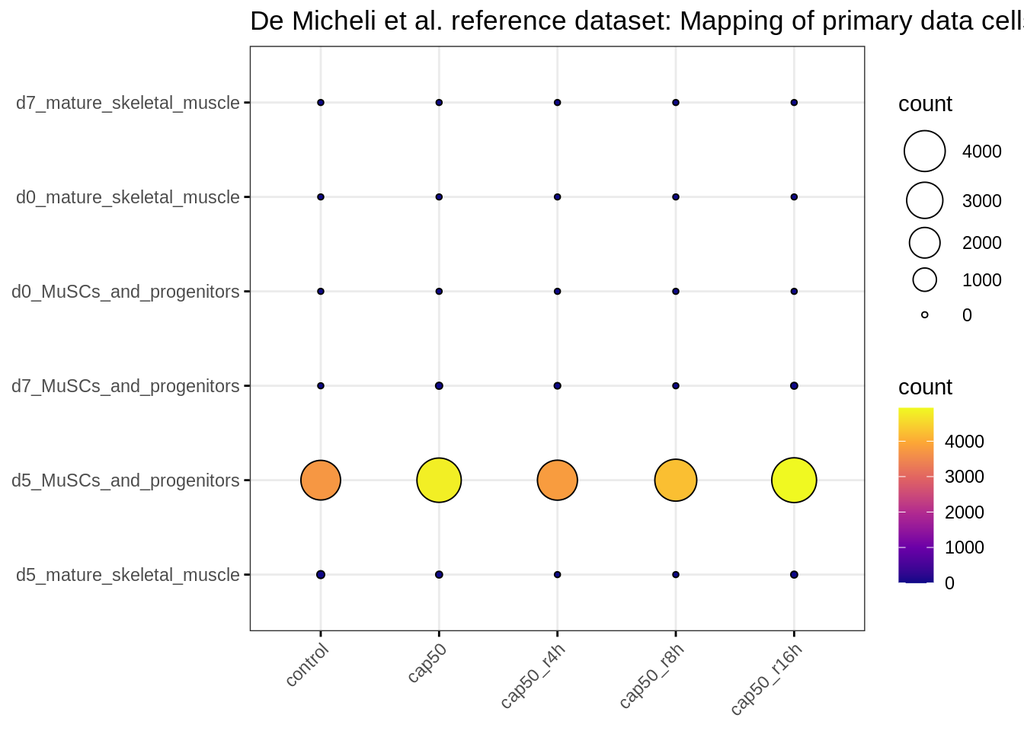

```r
colnames(df.dellOrso) <- c("cell_type", "sample", "count")

# Add missing cell types
df.deMicheli.missing.rows <- data.frame("cell_type" = c(rep("d0_MuSCs_and_progenitors", 5), rep("d0_mature_skeletal_muscle", 5), rep("d7_mature_skeletal_muscle", 5)),
                                        "sample" = rep(c("control", "cap50", "cap50_r4h", "cap50_r8h", "cap50_r16h"), 3),
                                        "count" = rep(0, 15))
df.dellOrso.missing.rows <- data.frame("cell_type" = rep("homeostatic_MuSCs", 5),
                                       "sample" = c("control", "cap50", "cap50_r4h", "cap50_r8h", "cap50_r16h"),
                                       "count" = rep(0, 5))

df.deMicheli <- rbind(df.deMicheli, df.deMicheli.missing.rows)
df.dellOrso <- rbind(df.dellOrso, df.dellOrso.missing.rows)

# De Micheli balloon plot
balloon.deMicheli <- ggballoonplot(df.deMicheli, x = "sample", y = "cell_type", size = "count",
              fill = "count", ggtheme = theme_bw()) +
  scale_fill_viridis_c(option = "C") +
  ggtitle("De Micheli et al. reference dataset: Mapping of primary data cells shown in a balloonplot")

# Dell Orso balloon plot
balloon.dellOrso <- ggballoonplot(df.dellOrso, x = "sample", y = "cell_type", size = "count",
              fill = "count", ggtheme = theme_bw()) +
  scale_fill_viridis_c(option = "C") +
  ggtitle("Dell'Orso et al. reference dataset: Mapping of primary data cells shown in a balloonplot")

balloon.deMicheli
```

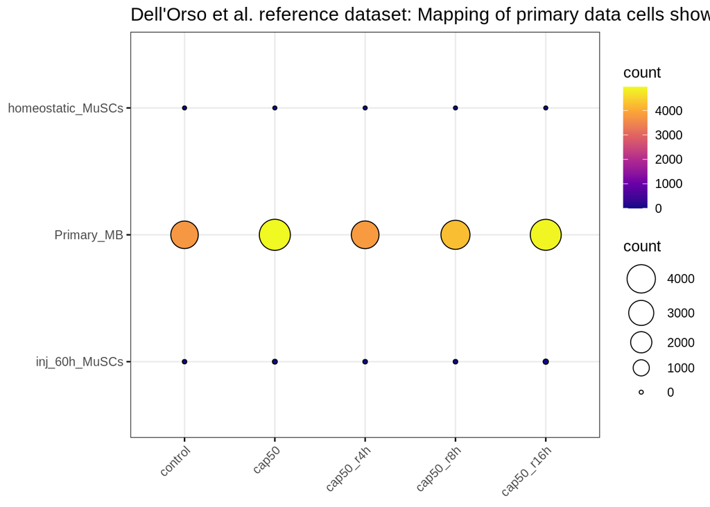

```r
balloon.dellOrso
```

### 5.2 Without cell cycle genes

```r
table(pred.deMicheli.cc.genes$pruned.labels)
```

```
##
## d5_mature_skeletal_muscle  d5_MuSCs_and_progenitors  d7_MuSCs_and_progenitors
##                        27                     21516                        80
```

```r
table(pred.dellOrso.cc.genes$labels)
```

```
##
## inj_60h_MuSCs    Primary_MB
##            46         21762
```

```r
tab.deMicheli.cc.genes <- t(table(pred.deMicheli.cc.genes$pruned.labels, denoised.sce.cc.genes$sample)[, c("control", "cap50", "cap50_r4h","cap50_r8h","cap50_r16h")])

tab.dellOrso.cc.genes <- t(table(pred.dellOrso.cc.genes$pruned.labels, denoised.sce.cc.genes$sample)[, c("control", "cap50", "cap50_r4h","cap50_r8h","cap50_r16h")])

tab.deMicheli.cc.genes
```

```
##
##              d5_mature_skeletal_muscle d5_MuSCs_and_progenitors
##   control                           20                     3718
##   cap50                              4                     4820
##   cap50_r4h                          0                     3795
##   cap50_r8h                          0                     4244
##   cap50_r16h                         3                     4939
##
##              d7_MuSCs_and_progenitors
##   control                           7
##   cap50                            56
##   cap50_r4h                        11
##   cap50_r8h                         4
##   cap50_r16h                        2
```

```r
tab.dellOrso.cc.genes
```

```
##
##              inj_60h_MuSCs Primary_MB
##   control                1       3738
##   cap50                 16       4927
##   cap50_r4h              6       3801
##   cap50_r8h              3       4250
##   cap50_r16h            20       4916
```

### 5.3 De Micheli: segments on trajectory

```r
# Put predictions on a table
tab.deMicheli.segments <- table(denoised.sce$sample, pred.segments$pruned.labels)[c("control", "cap50", "cap50_r4h","cap50_r8h","cap50_r16h"),]
tab.deMicheli.segments.d5 <- table(denoised.sce$sample, pred.segments.d5$pruned.labels)[c("control", "cap50", "cap50_r4h","cap50_r8h","cap50_r16h"),]

tab.deMicheli.segments
```

```
##
##              segment_5 segment_6 segment_7 segment_8
##   control            1         4        19      3708
##   cap50              0         0         3      4964
##   cap50_r4h          0         0         7      3794
##   cap50_r8h          0         1         3      4246
##   cap50_r16h         0         0         3      4945
```

```r
tab.deMicheli.segments.d5
```

```
##
##              segment_10 segment_7 segment_8 segment_9
##   control          3716         2         1        28
##   cap50            5010         0         1         4
##   cap50_r4h        3802         0         0         8
##   cap50_r8h        4254         0         1         4
##   cap50_r16h       4947         0         2         3
```

```r
# Melt tables
df.deMicheli.s <- melt(tab.deMicheli.segments)
colnames(df.deMicheli.s) <- c("sample", "segment", "count")

df.deMicheli.s.d5 <- melt(tab.deMicheli.segments.d5)
```

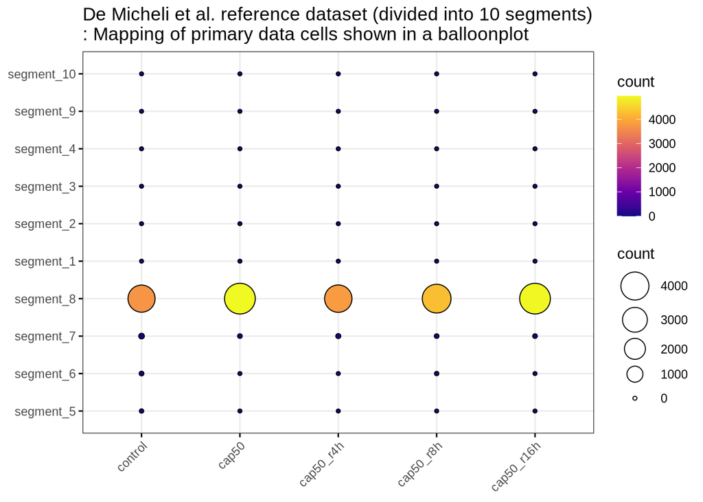

```r
colnames(df.deMicheli.s.d5) <- c("sample", "segment", "count")

# Add missing cell types
df.missing.rows.segments <- data.frame("sample" = rep(c("control", "cap50", "cap50_r4h", "cap50_r8h", "cap50_r16h"), 6),
                                       "segment" = c(rep("segment_1", 5), rep("segment_2", 5),rep("segment_3", 5),rep("segment_4", 5),
                                                     rep("segment_9", 5), rep("segment_10", 5)),
                                       "count" = rep(0, 30))

df.missing.rows.segments.d5 <- data.frame("sample" = rep(c("control", "cap50", "cap50_r4h", "cap50_r8h", "cap50_r16h"), 6),
                                       "segment" = c(rep("segment_1", 5), rep("segment_2", 5),rep("segment_3", 5),rep("segment_4", 5),
                                                     rep("segment_5", 5), rep("segment_6", 5)),
                                       "count" = rep(0, 30))

df.deMicheli.s <- rbind(df.deMicheli.s, df.missing.rows.segments)
df.deMicheli.s.d5 <- rbind(df.deMicheli.s.d5, df.missing.rows.segments.d5)

# De Micheli balloon plot
balloon.segments <- ggballoonplot(df.deMicheli.s, x = "sample", y = "segment", size = "count",
              fill = "count", ggtheme = theme_bw()) +
  scale_fill_viridis_c(option = "C") +
  ggtitle("De Micheli et al. reference dataset (divided into 10 segments)\n: Mapping of primary data cells shown in a balloonplot")

balloon.segments.d5 <- ggballoonplot(df.deMicheli.s.d5, x = "sample", y = "segment", size = "count",
              fill = "count", ggtheme = theme_bw()) +
  scale_fill_viridis_c(option = "C") +
  ggtitle("De Micheli et al. reference dataset (D5 MuSCs divided into 10 segments)\n: Mapping of primary data cells shown in a balloonplot")


balloon.segments
```

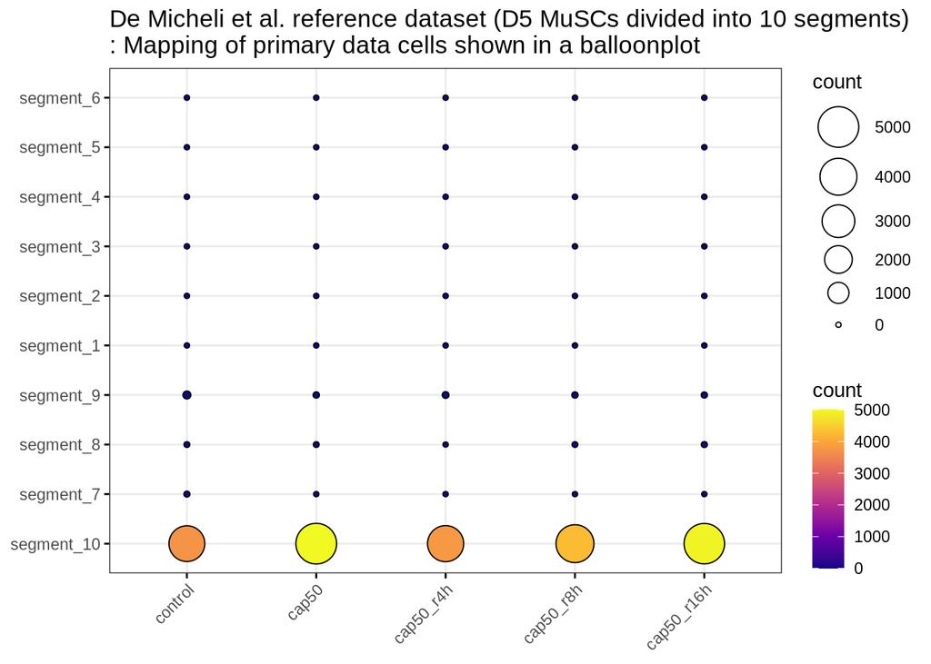

```r
balloon.segments.d5
```